# chapter_3

JEFFERSON SARANSIG

2026-09-15

```r
# Generate 50 random uniformly distributed numbers:
x <- runif(50)
# Check:
x
```

```
##  [1] 0.26819777 0.58075574 0.96818880 0.58626229 0.76695677 0.44492989
##  [7] 0.36845354 0.75466262 0.92578815 0.90447199 0.72108908 0.41162142
## [13] 0.37813696 0.35579653 0.46648348 0.06832002 0.05044242 0.88440083
## [19] 0.74687965 0.61675282 0.67117782 0.69915150 0.19519779 0.47095669
## [25] 0.57112980 0.92394924 0.92068821 0.13885294 0.53384047 0.57002877
## [31] 0.57628345 0.17858981 0.50417581 0.01355147 0.16942934 0.12567685
## [37] 0.83530914 0.59958424 0.85146118 0.83474979 0.22636947 0.65999359
## [43] 0.01236461 0.65672638 0.48869546 0.16389440 0.52017573 0.51160870
## [49] 0.88964991 0.25035661
```

```r
#para especificar rango de numeros
x <- runif(50, min = 2, max = 6)
head(x)
```

```
## [1] 5.976225 4.070681 2.054708 4.078707 2.865647 5.879187
```

Plottng a histogram

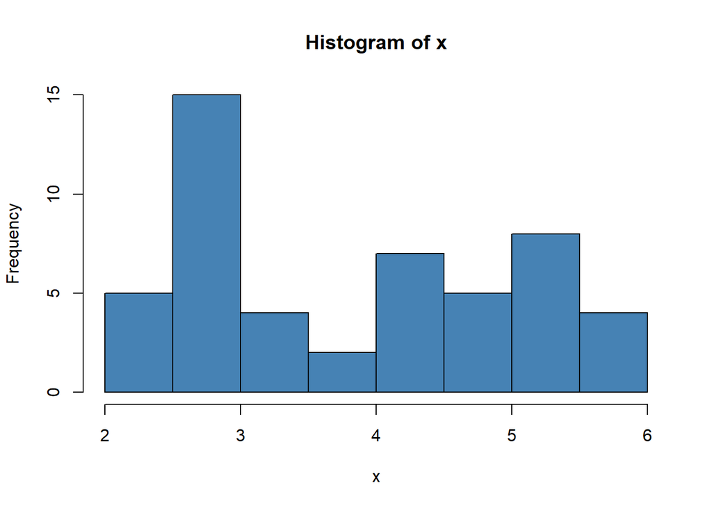

```r
hist(x, col = 'steelblue')
```

randmly distributed data

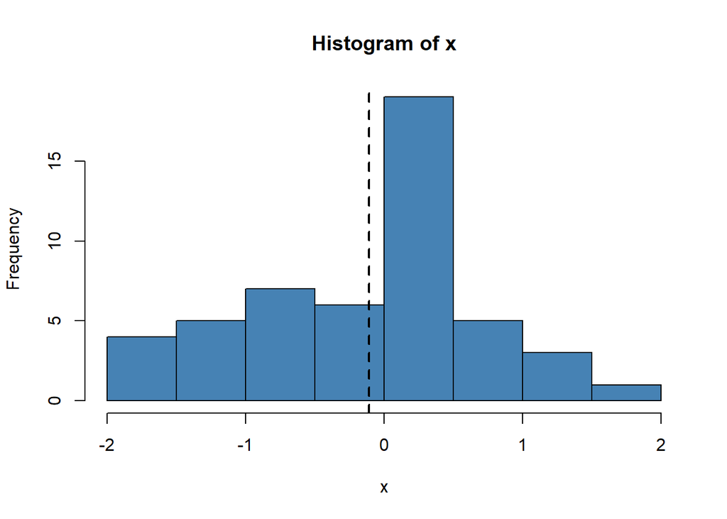

```r
x <- rnorm(50)
hist(x, col = 'steelblue')
abline(v = mean(x), lty = 2, lwd = 2) #lty is type of line --dashed, lwd is width of line
```

specifying option arguments mean and sd (asignando valores a mean y sd):

```r
x <- rnorm(50, mean = 5, sd = 2)
```

mean and sd:

```r
mean(x)
```

```
## [1] 5.053028
```

```r
sd(x)
```

```
## [1] 2.319481
```

quantile (where a certain percentage of your data falls below a specific point)

```r
quantile(x)
```

```
##        0%       25%       50%       75%      100%
## -1.656458  3.294898  5.199610  6.691458  9.630793
```

quantile 16

```r
quantile(x, 0.16)
```

```
##      16%
## 2.680674
```

quantile 84

```r
quantile(x, 0.84)
```

```
##     84%
## 7.27632
```

sanity check

```r
mean(x)-sd(x)
```

```
## [1] 2.733547
```

```r
mean(x)+sd(x)
```

```
## [1] 7.37251
```

```r
# 2.5th percentile:
quantile(x, 0.025)
```

```
##     2.5%
## 1.660572
```

```r
# Should correspond to M – 2 * SD:
mean(x) - 2 * sd(x)
```

```
## [1] 0.4140661
```

```r
# 97.5th percentile:
quantile(x, 0.975)
```

```
##    97.5%
## 9.438631
```

```r
# Should correspond to M + 2 * SD:
mean(x) + 2 * sd(x)
```

```
## [1] 9.691991
```

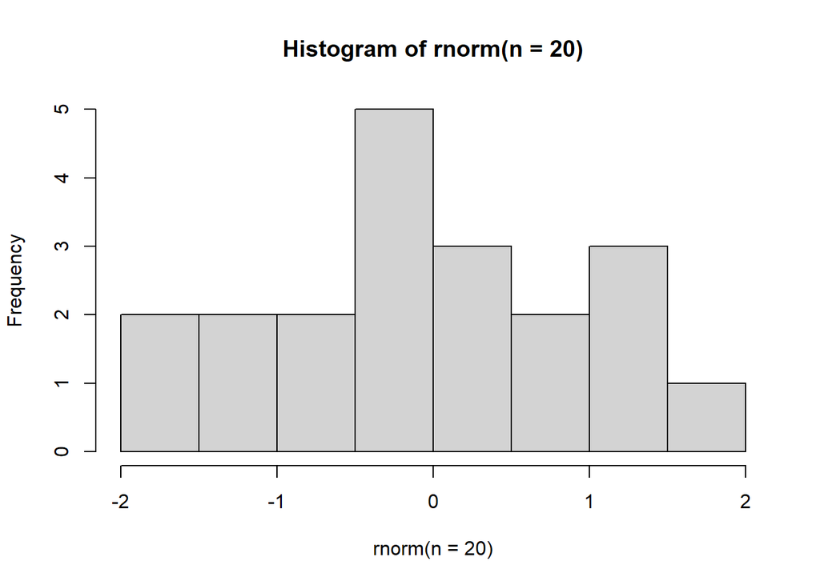

```r
#20 random numbers from a normal distribution (mean 0, SD 1)-not specified, see above
hist(rnorm(n = 20)) # execute repeatedly
```

Chapter 3 exercises

```r
war <- read_csv('warriner_2013_emotional_valence.csv')
war
```

```
## # A tibble: 13,915 × 2
##    Word          Val
##    <chr>       <dbl>
##  1 aardvark     6.26
##  2 abalone      5.3
##  3 abandon      2.84
##  4 abandonment  2.63
##  5 abbey        5.85
##  6 abdomen      5.43
##  7 abdominal    4.48
##  8 abduct       2.42
##  9 abduction    2.05
## 10 abide        5.52
## # ℹ 13,905 more rows
```

```r
range(war$Val)
```

```
## [1] 1.26 8.53
```

```r
filter(war, Val == min(Val) | Val == max(Val))
```

```
## # A tibble: 2 × 2
##   Word        Val
##   <chr>     <dbl>
## 1 pedophile  1.26
## 2 vacation   8.53
```

```r
filter(war, Val %in% range(Val))
```

```
## # A tibble: 2 × 2
##   Word        Val
##   <chr>     <dbl>
## 1 pedophile  1.26
## 2 vacation   8.53
```

```r
arrange(war, Val) # ascending order
```

```
## # A tibble: 13,915 × 2
##    Word        Val
##    <chr>     <dbl>
##  1 pedophile  1.26
##  2 rapist     1.3
##  3 AIDS       1.33
##  4 torture    1.4
##  5 leukemia   1.47
##  6 molester   1.48
##  7 murder     1.48
##  8 racism     1.48
##  9 chemo      1.5
## 10 homicide   1.5
## # ℹ 13,905 more rows
```

```r
arrange(war, desc(Val)) # descending order
```

```
## # A tibble: 13,915 × 2
##    Word        Val
##    <chr>     <dbl>
##  1 vacation   8.53
##  2 happiness  8.48
##  3 happy      8.47
##  4 christmas  8.37
##  5 enjoyment  8.37
##  6 fun        8.37
##  7 fantastic  8.36
##  8 lovable    8.26
##  9 free       8.25
## 10 hug        8.23
## # ℹ 13,905 more rows
```

```r
mean(war$Val)
```

```
## [1] 5.063847
```

```r
sd(war$Val)
```

```
## [1] 1.274892
```

```r
mean(war$Val) - sd(war$Val)
```

```
## [1] 3.788955
```

```r
mean(war$Val) + sd(war$Val)
```

```
## [1] 6.338738
```

```r
quantile(war$Val, c(0.16, 0.84))
```

```
##  16%  84%
## 3.67 6.32
```

```r
median(war$Val)
```

```
## [1] 5.2
```

```r
quantile(war$Val, 0.5)
```

```
## 50%
## 5.2
```

Exercises Ch.3 With the Warriner et al. (2013) data, create a ggplot2 histogram and plot the mean as a vertical line into the plot using geom_vline() and the xintercept aesthetic (see Chapter 2). Can you additionally add vertical dashed lines to indicate where 68% and 95% of the data lie? (Ignore any warning messages about binwidth that may arise).

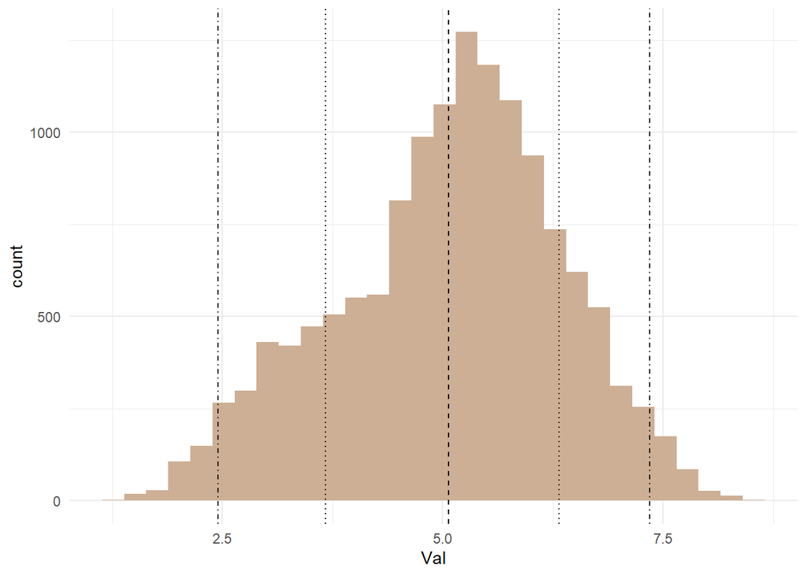

```r
ggplot(war, aes(x = Val)) +
  geom_histogram(fill = 'peachpuff3') +
  geom_vline(aes(xintercept = mean(war$Val)), linetype = 2) +
  geom_vline(xintercept = quantile(war$Val, c(0.16, 0.84)), linetype = 3) +
  geom_vline(xintercept = quantile(war$Val, c(0.025, 0.975)), linetype = 4) +
  theme_minimal()
```

Exercise 2:geo_histogram > geom_density

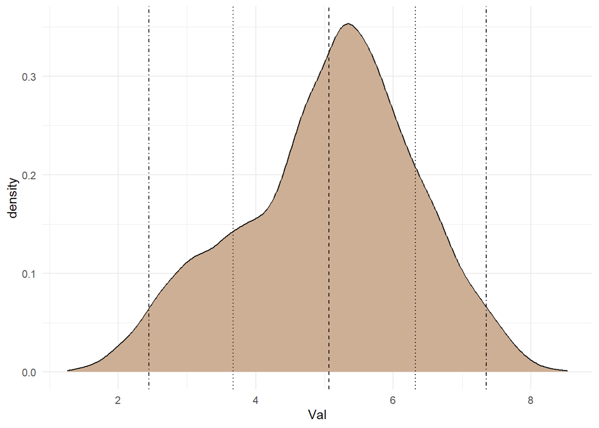

```r
ggplot(war, aes(x = Val)) +
  geom_density(fill = 'peachpuff3') +
  geom_vline(aes(xintercept = mean(war$Val)), linetype = 2) +
  geom_vline(xintercept = quantile(war$Val, c(0.16, 0.84)), linetype = 3) +
  geom_vline(xintercept = quantile(war$Val, c(0.025, 0.975)), linetype = 4) +
  theme_minimal()
```

Exercise 3 Imagine reading a research paper about a grammaticality rating study. It is noted that the mean acceptability rating for a particular grammatical construction is 5.25 with a standard deviation of 0.4. Assuming normality, what is the interval within which you expect 68% of the data to lie? What about 95% of the data? Do you think the assumption of approximate normality is reasonable in this case?

```r
M <- 5.25
SD <- 0.4

lower_68 <- M - SD
upper_68 <- M + SD

lower_68
```

```
## [1] 4.85
```

```r
upper_68
```

```
## [1] 5.65
```

95%

```r
lower_95 <- M - 2 * SD
upper_95 <- M + 2 * SD

lower_95
```

```
## [1] 4.45
```

```r
upper_95
```

```
## [1] 6.05
```

problem: Likert-scale data is discrete (only whole numbers are possible responses), while the normal distribution is a continuous model (mismatch) “While the calculated 68% and 95% intervals numerically fit within a plausible Likert scale (e.g., 1–7), there are still reasons to question the assumption of approximate normality. First, Likert-scale responses are discrete rather than continuous, which conflicts with the continuous nature that a normal distribution assumes. Second, since the mean (5.25) sits closer to the upper end of a typical scale, there is less room for values to spread out above the mean than below it, which could produce a skewed rather than symmetric distribution — undermining the normality assumption even though we cannot confirm this from the summary statistics alone.”